# Acoustic telemetry exploratory analysis

Actel R package (1.2.1)

### Summary

Target folder: C:/Users/Berlynna.Heres/Documents/github/HSCBrevardTelemetry

Timestamp: **2022-05-20 08:50:57**

Number of target tags: **15**

Number of listed receivers: **3** (of which **0** had no detections)

Data time range: 2022-01-25 07:51:00 to 2022-04-14 11:37:00 (EST).

Percentage of post-release valid detections: 100%

Found a bug? [**Report it here.**](https://github.com/hugomflavio/actel/issues)

Want to cite actel in a publication? Run `citation('actel')`

### Study area

Release sites are marked with “R.S.”. Arrays connected with an arrow indicate that the tags can only pass in one direction.

[figure not shown]

### Receiver stations

| Station.name | Latitude | Longitude | Section | Array | Standard.name |
| --- | --- | --- | --- | --- | --- |
| 487549-NE | 28.62577 | -80.78791 | Max_Brewer | GC | St.1 |
| 487550-SE | 28.62230 | -80.78625 | Max_Brewer | GC | St.2 |
| 487551-W | 28.62344 | -80.79027 | Max_Brewer | GC | St.3 |

### Deployments

| Receiver | Array | Station.name | Standard.name | Start | Stop |
| --- | --- | --- | --- | --- | --- |
| 487549 | GC | 487549-NE | St.1 | 2022-01-25 01:00:00 | 2022-04-14 13:00:00 |
| 487550 | GC | 487550-SE | St.2 | 2022-01-25 01:00:00 | 2022-04-14 13:00:00 |
| 487551 | GC | 487551-W | St.3 | 2022-01-25 01:00:00 | 2022-04-14 13:00:00 |

### Release sites

| Station.name | Latitude | Longitude | Array | Type | Standard.name | n.2022 |
| --- | --- | --- | --- | --- | --- | --- |
| Gator Creek | 28.62756 | -80.78707 | GC | Release | Gator_Creek | 15 |

### Warning messages

```
Warning: GUI is set to 'needed' but packages 'gWidgets2RGtk2', 'RGtk2' are not available. Please install them if you intend to run GUI.
         Disabling GUI (i.e. GUI = 'never') for the current run.
Warning: 'speed.warning'/'speed.error' were not set, skipping speed checks.
Warning: 'inactive.warning'/'inactive.error' were not set, skipping inactivity checks.
```

### User comments

```
No comments were included during the analysis.
```

### Average time of arrival at each Array

**Note:**

Coloured lines on the outer circle indicate the mean value for each group and the respective ranges show the standard error of the mean. Each group’s bars sum to 100%. The number of data points in each group is presented between brackets in the legend of each pannel.

You can replicate these graphics and edit them as needed using the `plotTimes()` function.

The data used in these graphics is stored in the `times` object.

[figure not shown]

### Individual detection plots

**Note:**

You can choose to plot detections by station or by array using the `detections.y.axis` argument.

Manually **edited** tags are highlighted with **yellow** graphic borders.

The arrays have been aligned by section, following the order provided either in the spatial input or the `section.order` argument.

You can replicate these graphics and edit them as needed using the `plotDetections()` function.

You can also see the movement events of multiple tags simultaneously using the `plotMoves()` function.

The data used in these graphics is stored in the `detections` and `movements` objects (and respective valid counterparts).

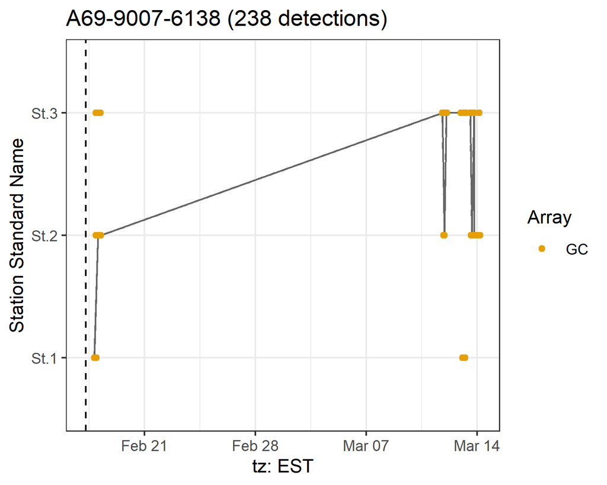

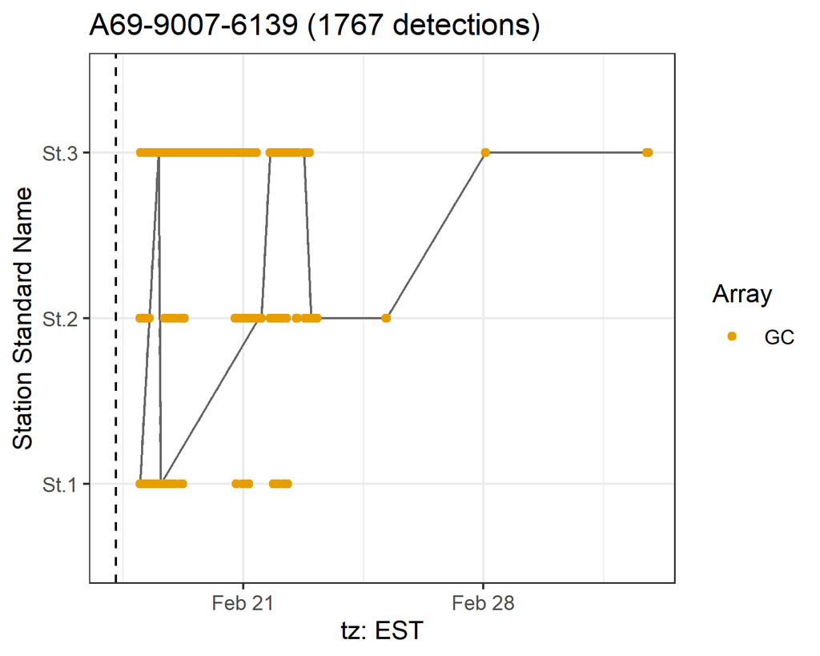

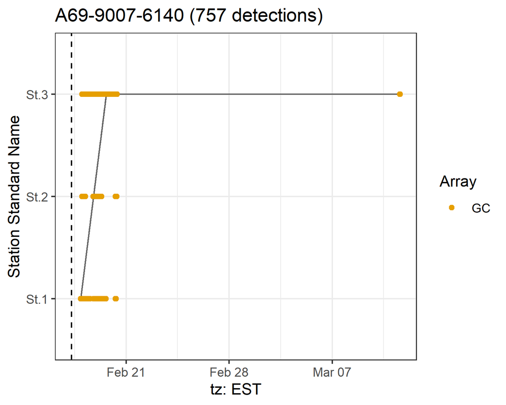

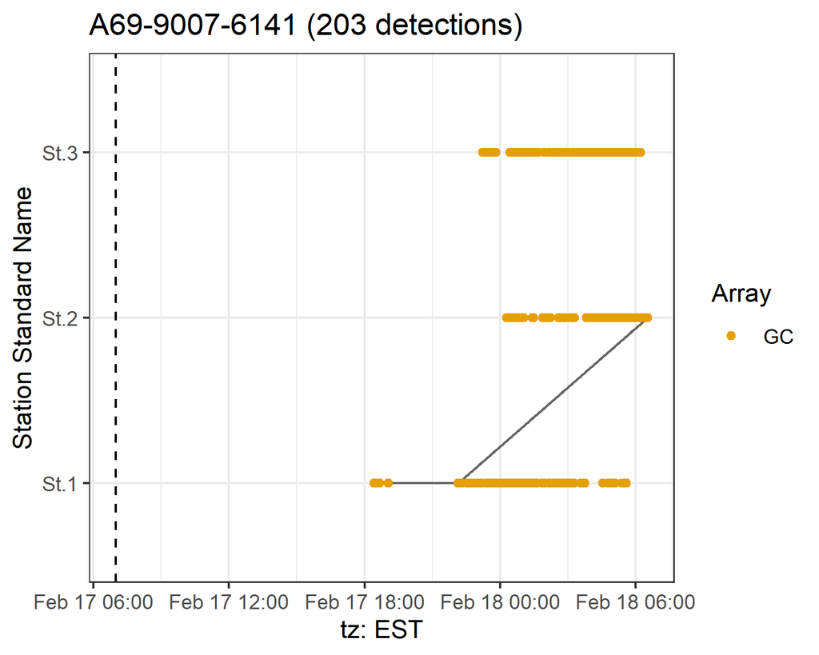

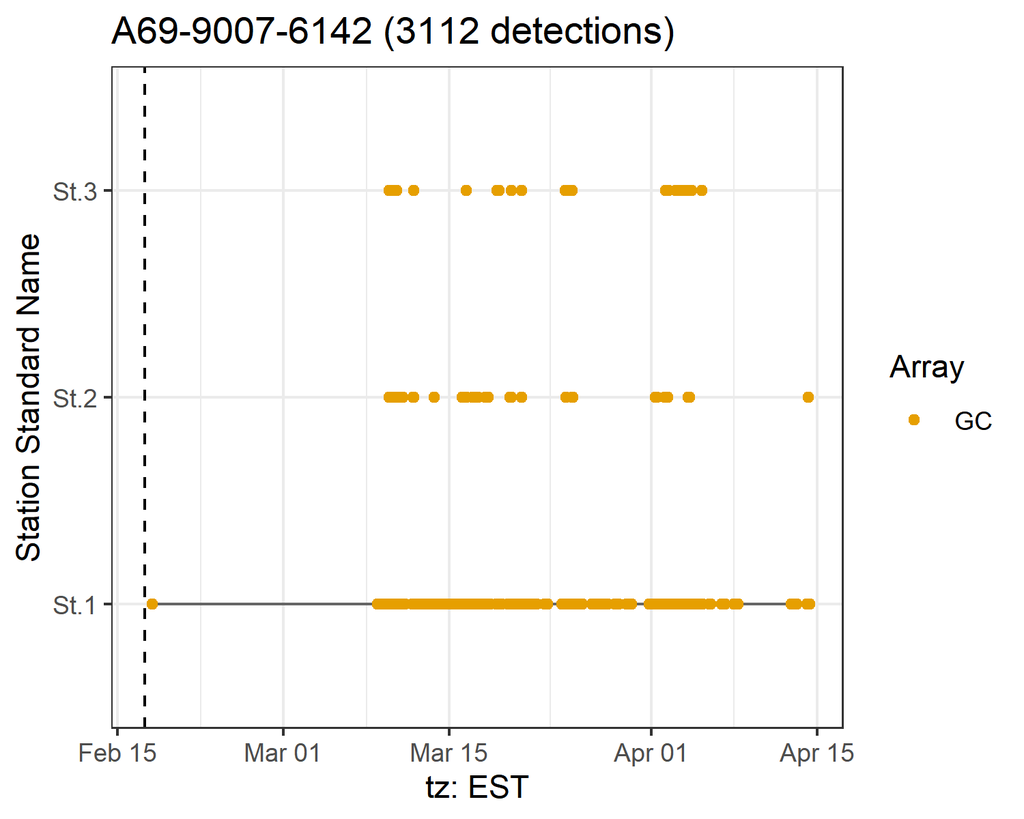

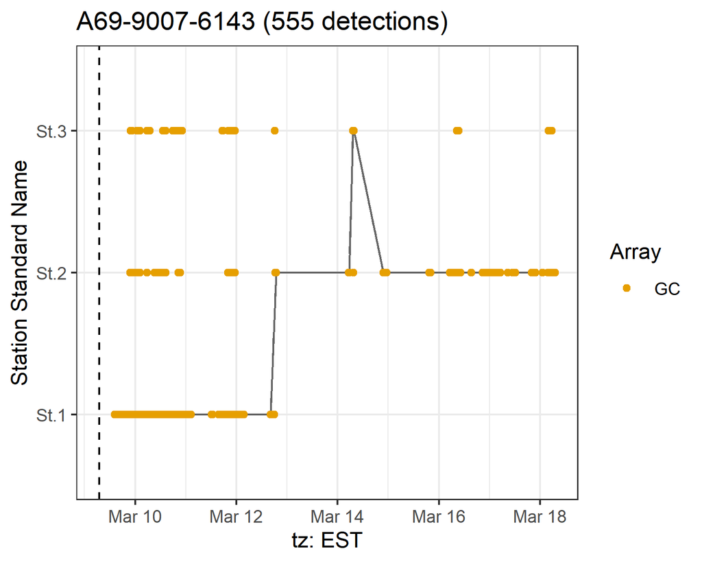

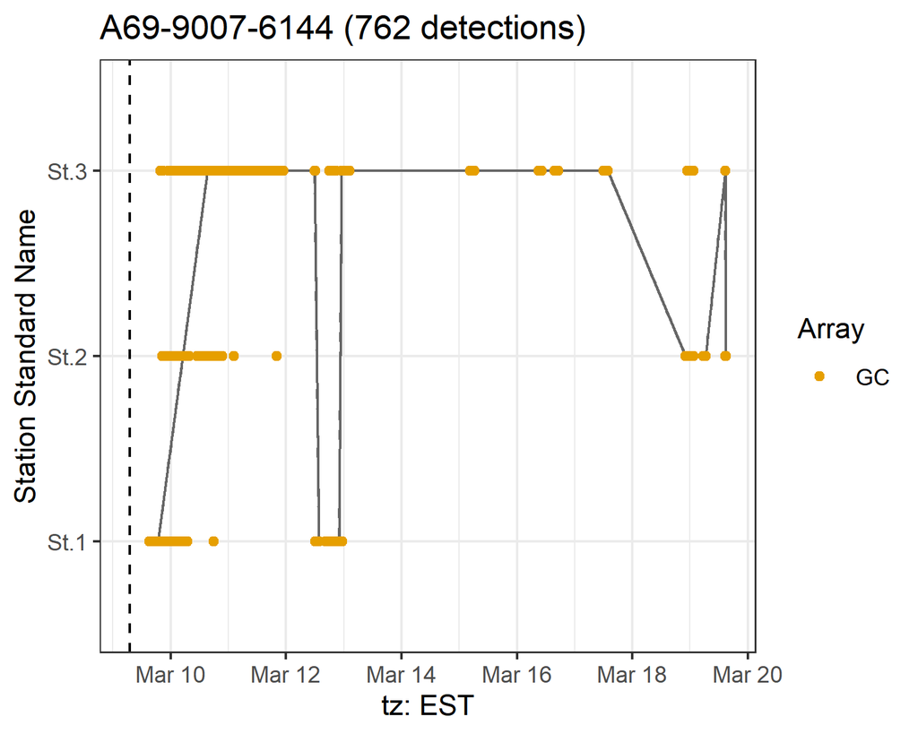

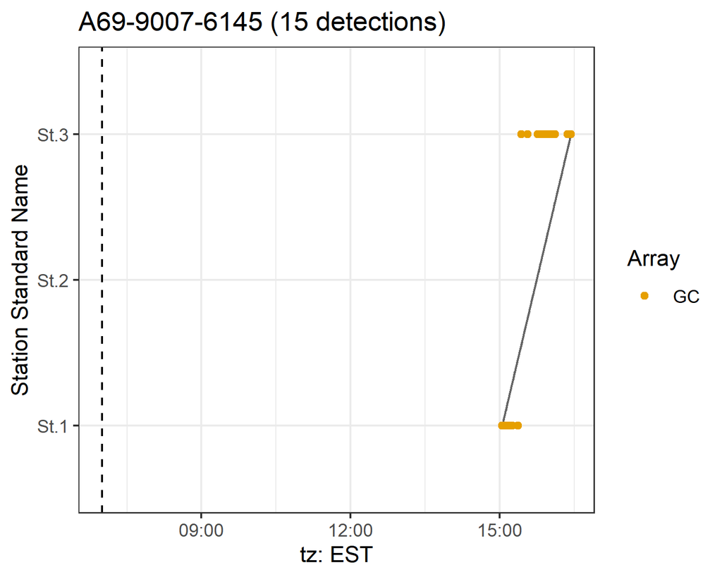

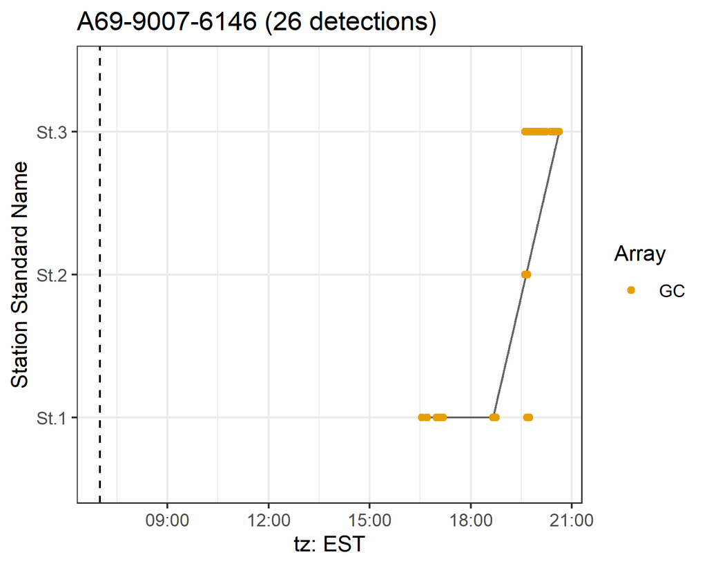

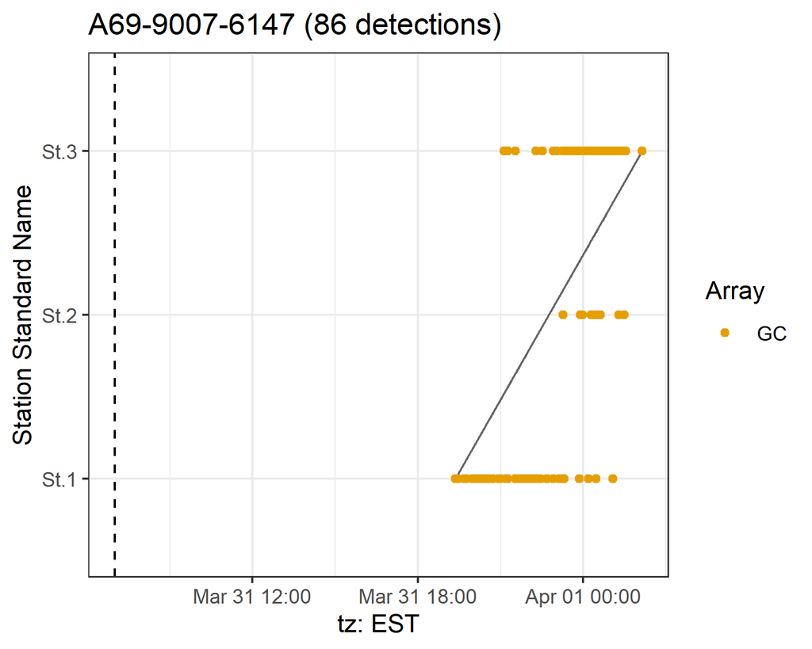

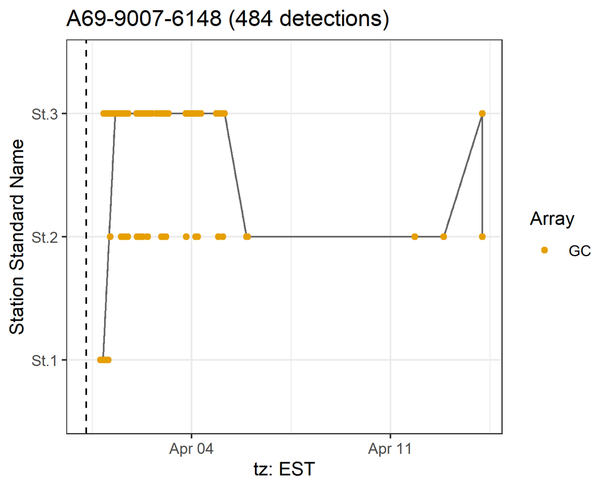

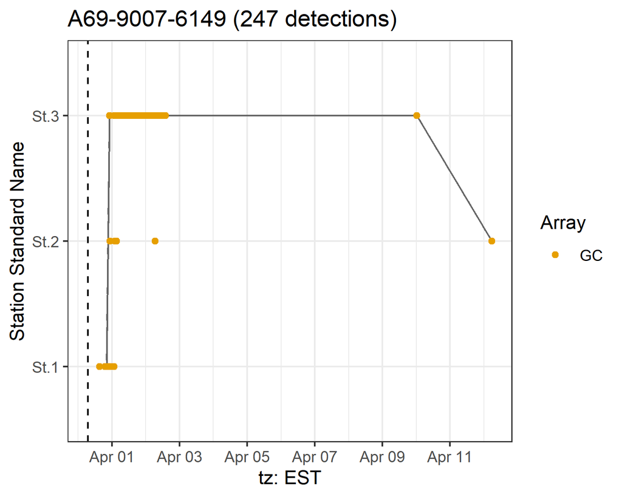

[3 more figures not shown]

### Sensor plots

**Note:**

The data used for these graphics is stored in the `valid.detections` object.

You can replicate these graphics and edit them as needed using the `plotSensors()` function.

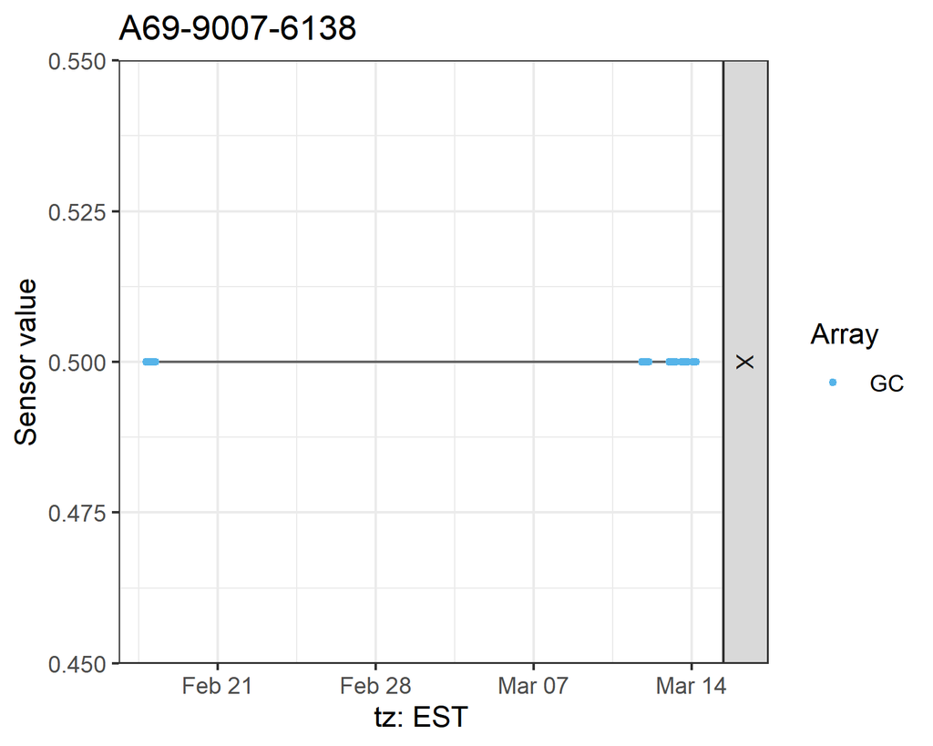

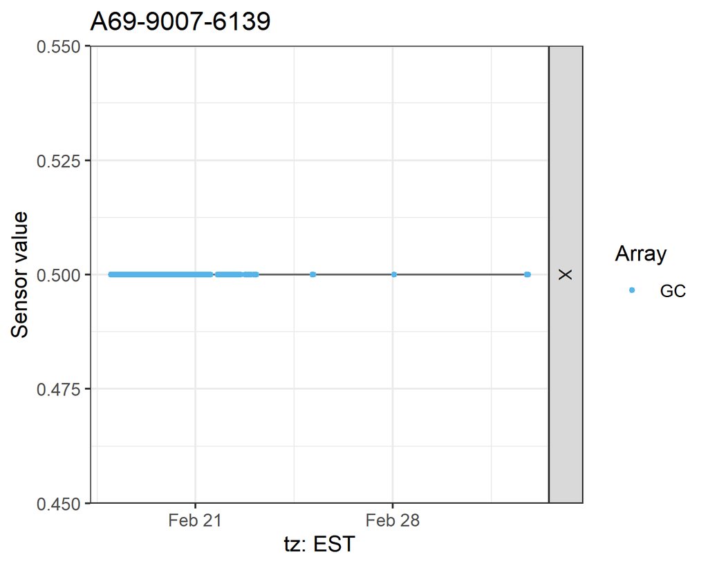

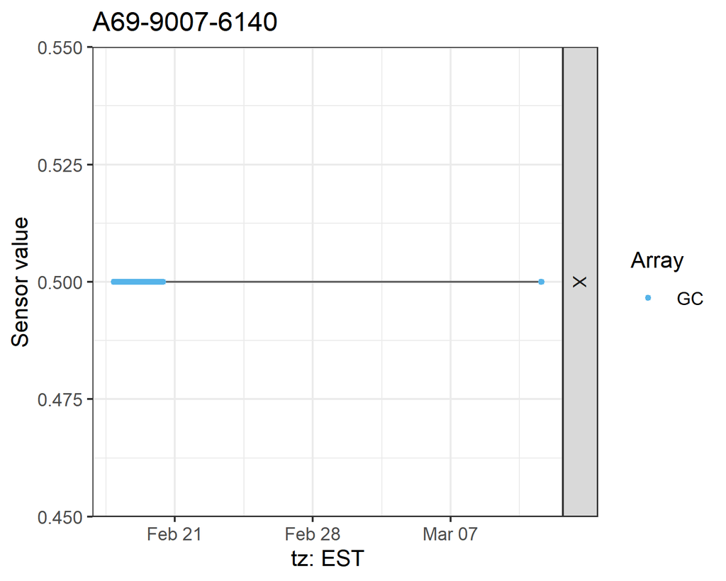

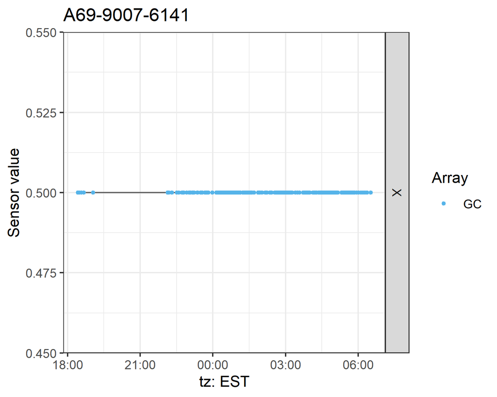

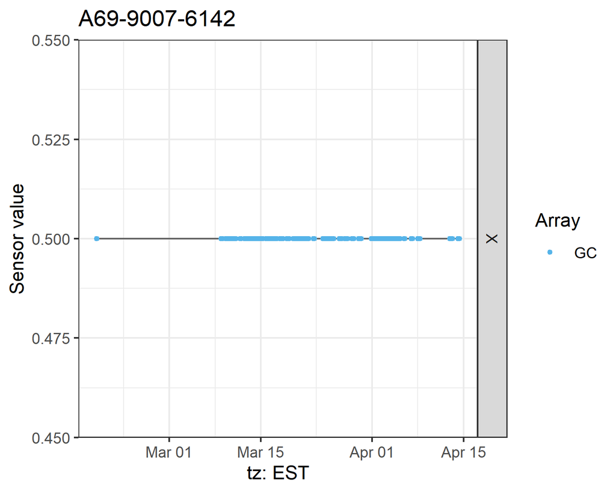

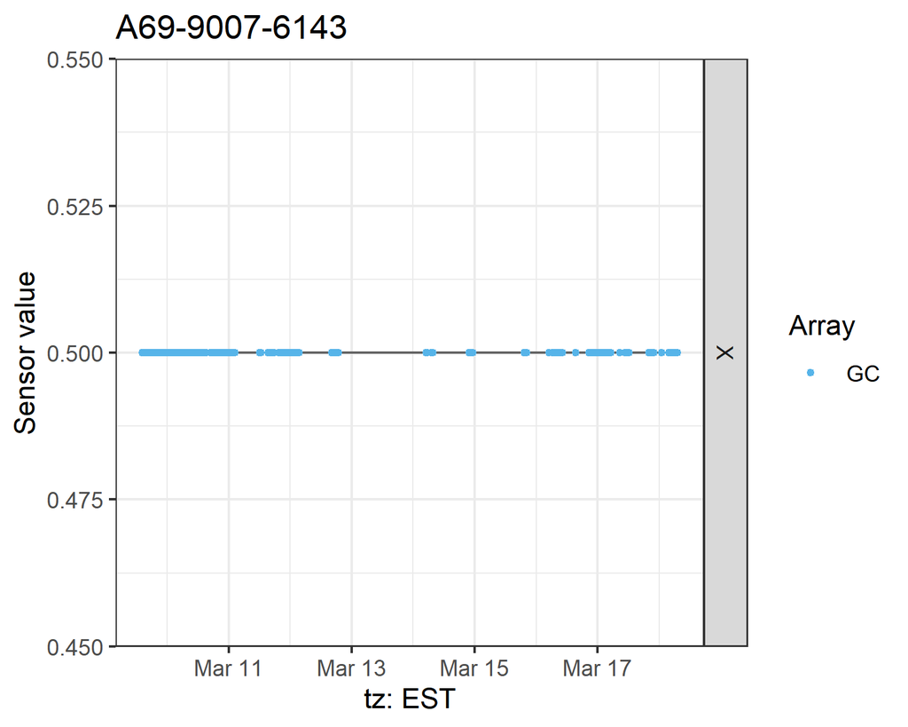

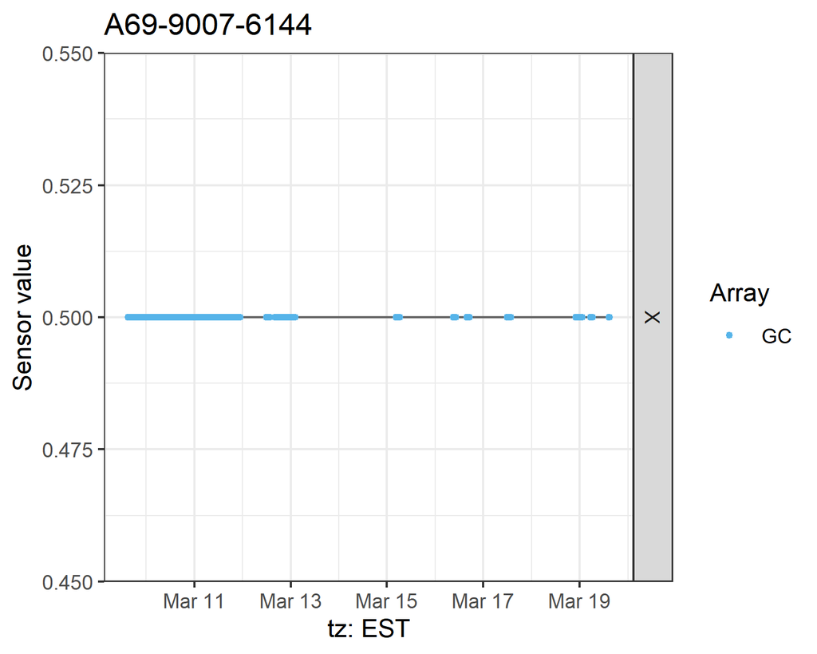

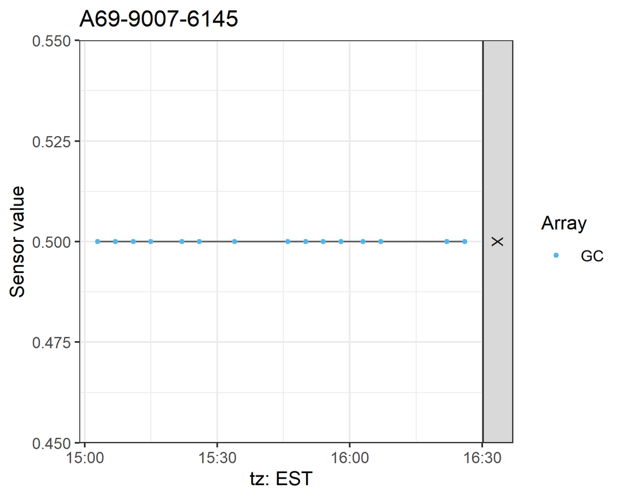

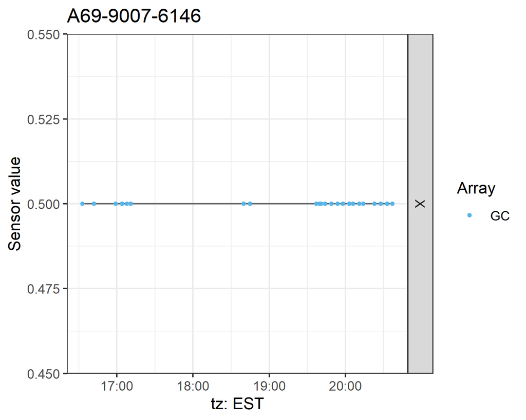

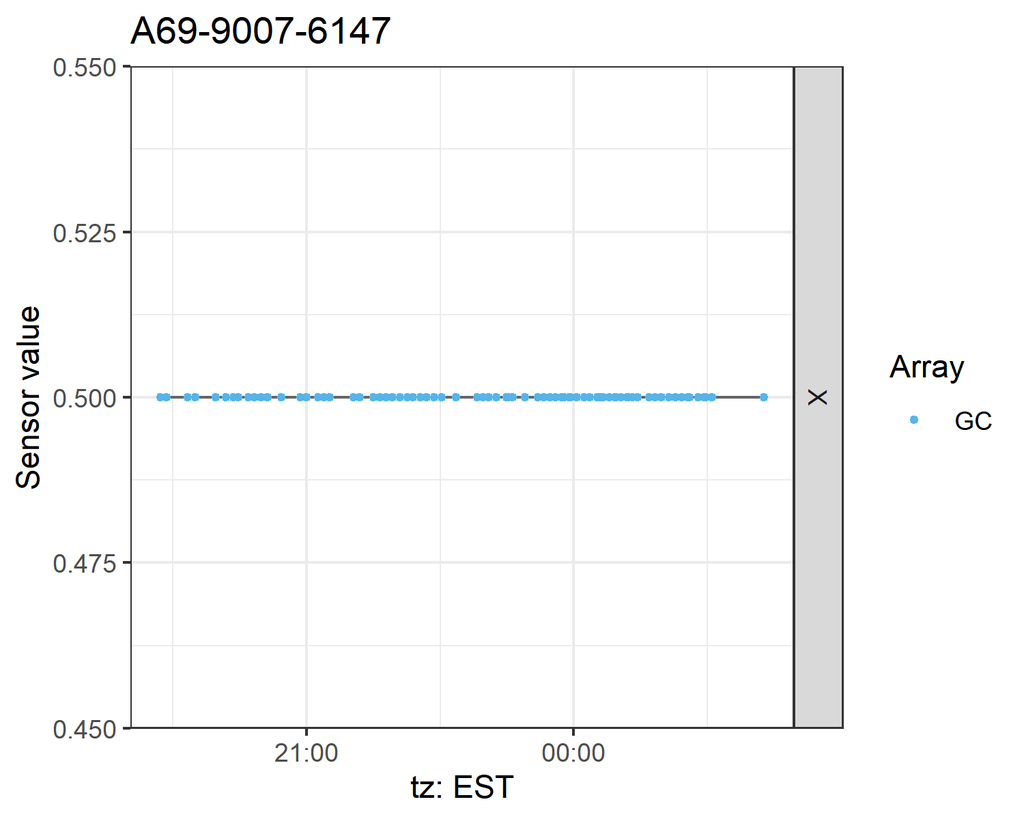

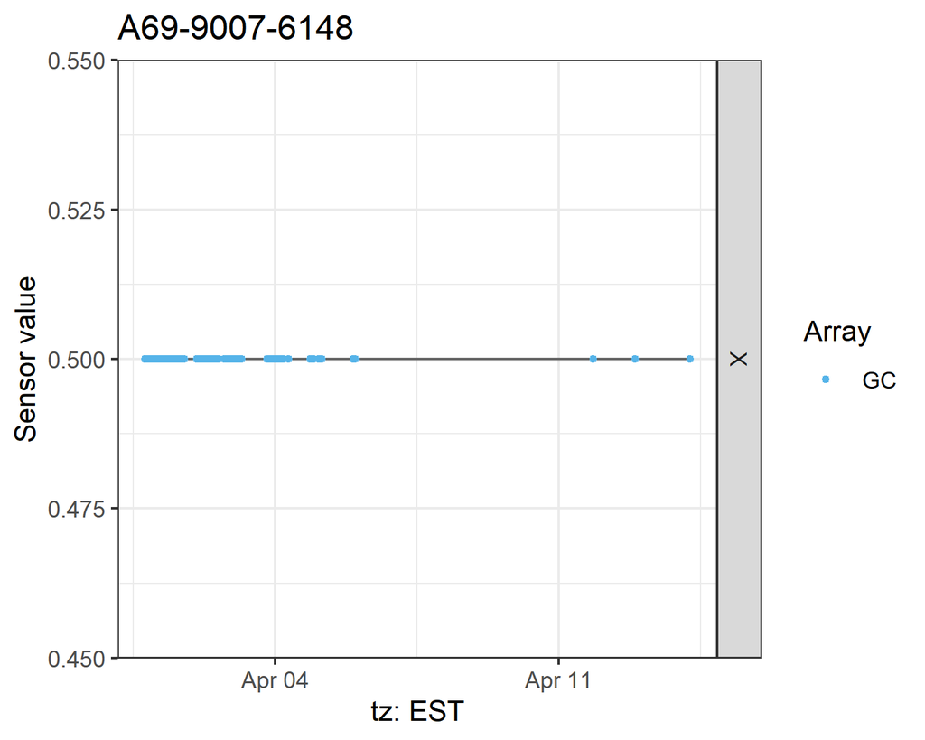

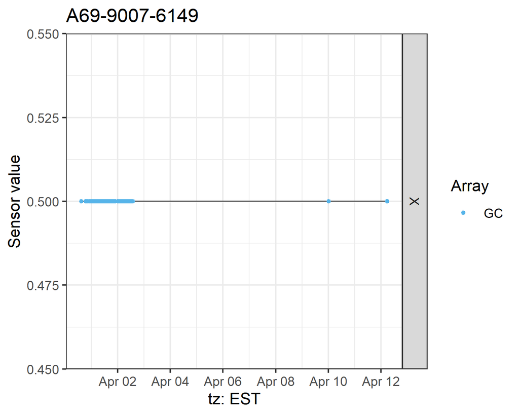

[3 more figures not shown]

### Full log

[output not shown]

Index:

Summary Study area Stations Deployments Release sites Warnings Comments Arrival times Individual detections Sensor data Full log